# WhatsApp analysis

# Introduction and background

I started this project to test out some R packages I’d been meaning to learn. I thought WhatsApp messages between my wife and I would be a fun dataset to start with.Of course, as I looked more into the data, other questions came up and new R packages came to my attention, leading to other side projects, and so on. I decided finally to hit the pause button and to share what I had to-date.

There are still a few text mining and Natural Language Processing (NLP) methods I want to do but that will have to come later.

Not all the code chunks will be shared here. If you’re interested in seeing all the underlying code and notes, check out the file in Github.

### Packages

Below are the R packages I used, grouped by their function: text mining/NLP, data cleaning and processing, data visualization, and miscellaneous.

#### Text mining/NLP

- **tm** text mining. Use for converting vectors to Source objects; preprocessing/cleaning functions
- **SnowballC** provides a wordStem() function, which for a character vector, returns the same vector of terms in its root form
- **syuzhet** takes a body of text and identifies which emotions it represents and whether the emotion is positive or negative

#### Data cleaning and processing

- **lubridate** for working with dates
- **janitor** for cleaning and processingdata (e.g. recoding variables, renaming, dealing with missing values, and creat)
- **stringr** for working with text (e.g. extracting and finding words)

#### Data visualization packages

- **knitr** for presenting tables in html
- **wordcloud** to make pretty word clouds
- **wordcloud2** to do more with wordclouds in html
- **ggthemes** for adding ggplot themes to charts
- **viridisLite** for color schemes that can be perceived by colorblind readers
- **ggalt** to create lollipop charts
- **DT** to easily create interactive data tables
- **kableExtra** for creating nicely formatted (but static) data tables
- **highcharter** for making interactive html charts. Itprovides an R interface to the Highcharts JavaScript graphics library

#### Miscellaneous

- **tidyverse** for loading all the core Hadley Wickham packages (e.g. ggplot2, dplyr, forcats, etc.)
- **devtools** for installing packages directly from github
- **rwhatsapp** nicely prepares and structures a whatsapp text file for use in R
- **pacman** useful for installing and/or updating many packages at once

After loading all the packages and importing the dataset, I create the corpus using the tm package.

```r
texts <- readLines("whatsapp.txt")
#create the corpus using tm

docs <- Corpus(VectorSource(texts)) #fully kept in memory and optimized for importing, preprocessing, and transforming texts. However, some limitations to minimize memory pressure

docs2 <- VCorpus(VectorSource(texts)) #use this when using transformations that can't process character vectors and return character vectors (of the same length)
```

The next step is to apply cleaning functions to the entire corpus (this can take a minute).

```r
# These steps replace common signs with a space
# content_transformer is used to create a wrapper to get and set the content of text documents
trans <- content_transformer(function(x, pattern) gsub(pattern, " ", x))
clean_corp <- tm_map(docs2, trans, "://(.*)") #remove everything after ://
clean_corp <- tm_map(docs2, trans, "@")
clean_corp <- tm_map(docs2, trans, "\\|")

# It's easier to create a custom function so that you can apply the same functions over multiple corpora
clean_corpus <- function(corpus){
  corpus <- tm_map(corpus, removePunctuation,
                   preserve_intra_word_contractions = TRUE,
                   preserve_intra_word_dashes = TRUE)
  corpus <- tm_map(corpus, content_transformer(tolower)) # use content_transformer when using base R functions like tolower()
  corpus <- tm_map(corpus, removeWords, c(stopwords("en"), "hannah guedenet", "media","omit", "charles","omitted"))
  corpus <- tm_map(corpus, stripWhitespace)
  corpus <- tm_map(corpus, removeNumbers)
  #corpus <- tm_map(corpus, stemDocument, language = "english")
  return(corpus)
}

#apply preprocessing function to textCorpus (corpus of qual data)
clean_corp <- clean_corpus(clean_corp)
```

Finally, it’s time to create frequency matrices of the corpus

# Word frequencies

Now the fun starts! I can start looking at word frequencies. What words were used most in whatsApp messages?

It’s also interesting that “sorry” comes up at about the same frequency. However, it sounds about right to me that people who love each other can also apologize to each other.

Words like “get”, “home”, “now”, or “going” are also in the top 10 and this likely reflects the fact that much of our WhatsApp communication is about logistics (i.e., when I’ll be leaving work, where I’m going, or when I expect to get home).The word “girls” refers to our two daughters.

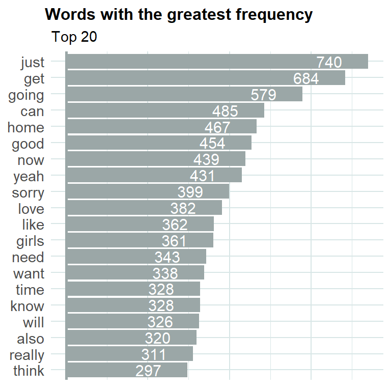

**Simple word cloud**

Words that appear in at least 100 messages

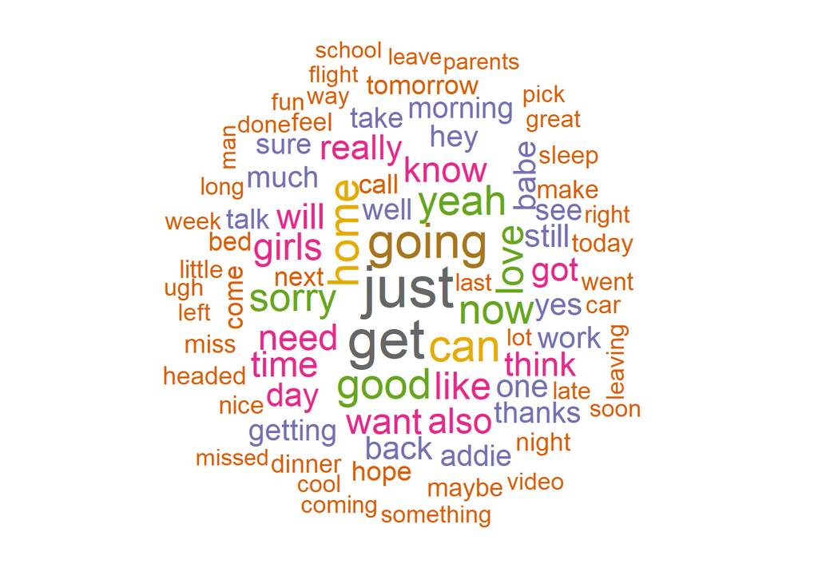

# Word co-occurence

Love has a co-occurence of 14% and 13% with beaucoup and much. The “beaucoup” means “a lot” in French, which we use occasionally in our texts.

| words | co-occurence |
| --- | --- |
| beaucoup | 0.14 |
| much | 0.13 |

I like that “hugs” has the highest co-occurence with “girls” at 23% although that is quickly followed by words that refer to more practical day-to-day logistics like “give” and “bath” (said in the context of giving our daughters baths).

| words | co-occurence |
| --- | --- |
| hugs | 0.23 |
| give | 0.14 |

# Compare messages by author

| author | min | max | mean | median | count |
| --- | --- | --- | --- | --- | --- |
| Charles | 1 | 599 | 41.67036 | 30 | 5142 |
| Hannah | 1 | 519 | 41.24456 | 30 | 8178 |

| author | n | percent |
| --- | --- | --- |
| Charles | 5142 | 39% |
| Hannah | 8178 | 61% |

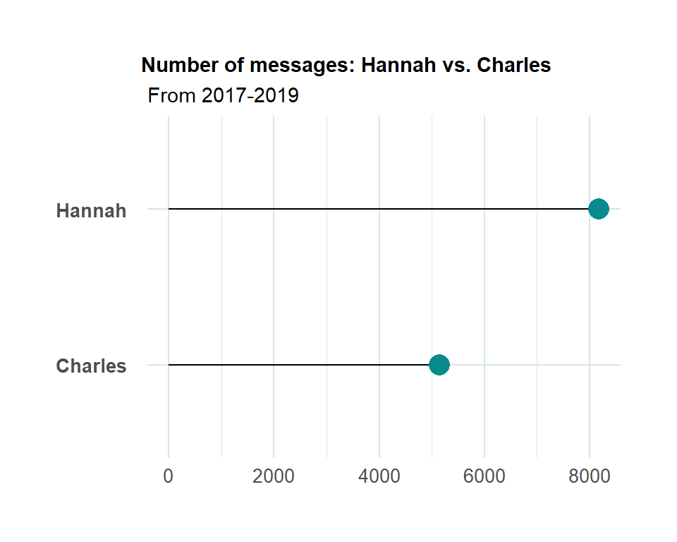

# Extract URLs

### Search all news stories shared on nyt, wapo, and npr

Hannah shared some good news stories over the last couple of years. I’ve extracted all the stories from New York Times, Washington Post, NPR, and the BBC to get a feel for what news we thought was worth sharing with each other.

|  | time | author | text |
| --- | --- | --- | --- |
| 6583 | 2018-08-01 09:14:00 | Hannah | https://www.nytimes.com/2018/07/17/style/aperol-spritz-drink-summer.html |
| 10777 | 2019-01-15 08:41:00 | Hannah | https://www.nytimes.com/2019/01/15/world/africa/nairobi-attack.html |
| 12017 | 2019-03-07 04:13:00 | Hannah | 9 Ways to Cut Down on Plastic https://www.nytimes.com/2019/02/16/style/plastic-how-to-use-less.html |
| 4270 | 2018-03-26 04:42:00 | Hannah | https://www.washingtonpost.com/news/capital-weather-gang/wp/2018/03/23/new-forecast-cherry-blossoms-wont-reach-peak-bloom-until-around-april-10/ |
| 6378 | 2018-07-29 07:20:00 | Hannah | https://www.washingtonpost.com/investigations/white-house-uses-foreign-aid-agency-to-give-jobs-to-trump-loyalists/2018/07/28/3f819ac2-86da-11e8-8589-5bb6b89e3772_story.html |
| 8226 | 2018-10-20 19:41:00 | Hannah | https://www.washingtonpost.com/outlook/fallen-star-wayne-rooney-saved-his-soccer-career--and-dcs-team-along-with-it/2018/10/18/d23a4b26-d2f6-11e8-b2d2-f397227b43f0_story.html |
| 7770 | 2018-09-28 07:02:00 | Charles | have you heard of Planet Money’s new podcast “The Indicator”? Good stuff. https://www.npr.org/templates/transcript/transcript.php?storyId=640595850?storyId=640595850 |
| 1928 | 2017-11-25 13:37:00 | Hannah | https://www.npr.org/2017/07/25/539092670/you-2-0-the-value-of-deep-work-in-an-age-of-distraction |
| 7781 | 2018-10-01 11:42:00 | Hannah | https://www.npr.org/sections/ed/2018/10/01/605213122/5-simple-ways-to-encourage-brain-development-in-your-little-one |
| 5992 | 2018-06-23 23:40:00 | Charles | https://www.bbc.co.uk/news/amp/world-africa-44586218 |

# Visualizing messages over time

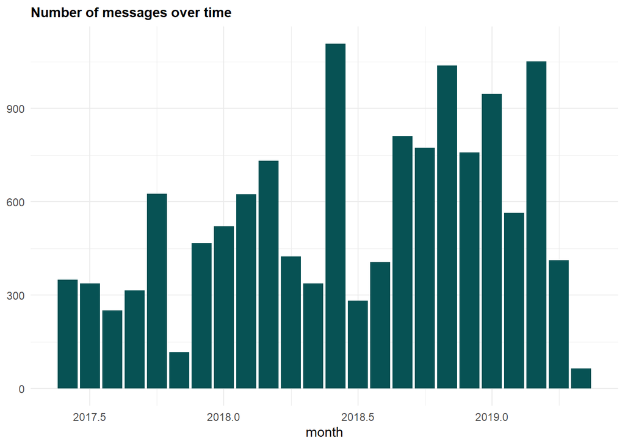

# Analyzing sentiment  
I analyzed our text messages for emotions and sentiments. There are a few limitations of this approach:  
1. Longer messages will have more positive and negatively associated words that may cancel each other out;  
2. Smaller messages may communicate strong emotions but not show up in the top ten because they’re short;  
3. The lexicon I used does not do always do a good job of detecting emotions partly because it doesn’t get sarcasm or negated words (e.g. “not happy”); and  
4. We sometimes forward other people’s messages so the emotion doesn’t necessarily reflect our own feelings although this is fairly rare.

### Here is a word cloud composed entirely of words from our whatsApp messages tagged as expressing “joy” sentiments. The size corresponds to the frequency of the words.

[interactive chart not shown]

# Sentiment over time

There’s a significant drop in the number of messages on Sunday which makes sense since we’re together most of the day. There’s still a fair bit of messaging on Saturday but that’s likely because we spend part of the day apart, taking one of our daughters to various activities while the other stays home. Both Saturday and Sunday are our most positive days.

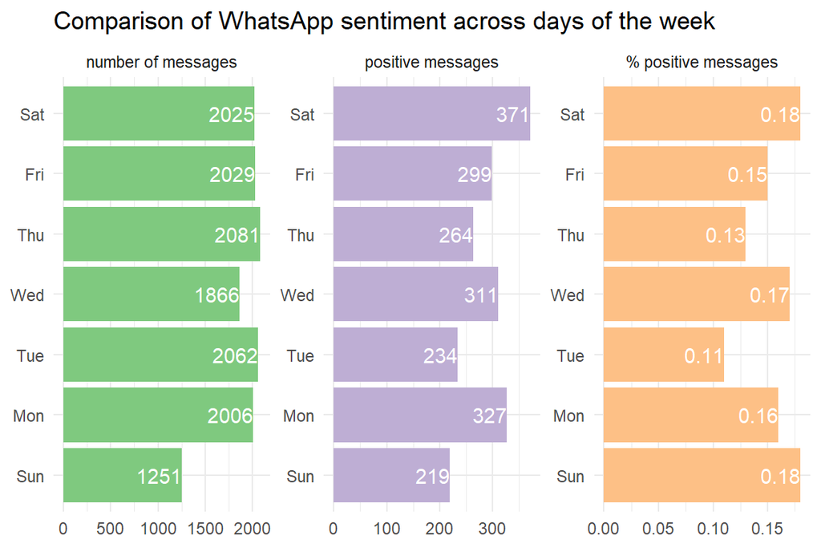

[figure not shown]